# Neighbours by boundaries or by trips: endemic-epidemic models of COVID-19 in Catalunya

Author

Prince Oppong Boakye

Published

November 28, 2026

# 1 Introduction

COVID-19 spreads between basic health areas (ABS) as well as within them. The endemic-epidemic model `hhh4` (Meyer and Held 2014; Meyer et al. 2017) splits the cases in each area and time period into three parts:

- **Endemic**: cases not linked to recent cases, in proportion to population.
- **Autoregressive**: cases from past cases in the same ABS.
- **Neighbour**: cases from past cases in other ABS.

The neighbour component needs weights that define which ABS are linked and how closely. Standard models base these weights on shared borders. People often travel beyond adjacent areas, so trips may describe contact between ABS better. We test this on weekly cases in Catalunya’s 374 ABS from 22 March 2020 to 1 May 2021, with neighbours defined by shared boundaries, by trip orders or by trip shares. We compare the three by in-sample fit, one-week-ahead forecasts and how the fitted cases split across the components, and check whether the ranking holds with temperature and restrictions. We also check whether people’s destinations changed with the restrictions, and how they differ between urban and rural ABS.

The data combine five sources:

- **Cases**: confirmed COVID-19 counts from BSC Flow-Maps (Ponce-de-Leon and Pontes 2024), with two ABS taken from the official CatSalut series.
- **Mobility**: daily trips between ABS from MITMA (Niraula and Oppong Boakye 2026).
- **Population**: the 2021 registered population of each ABS (CatSalut).
- **Temperature**: daily mean temperature by ABS (AEMET).
- **Restrictions**: the dates of the national and Catalan decrees (BOE, DOGC).

# 2 Data

## 2.1 Setup

```r
suppressMessages({
    library(surveillance)
    library(sf)
    library(ggplot2)
    library(dplyr)
    library(tidyr)
    library(patchwork)
})

# Input folders: the Catalunya panel (Spain-data) and the derived inputs of
# bayesian-end-epi-mobility; set SPAIN_DATA and INPUTS to use other locations
spain = \(...) file.path(Sys.getenv("SPAIN_DATA", "../Spain-data"), ...)
out = \(f) file.path(Sys.getenv("INPUTS", "../slater/outputs"), f)

# Plot theme and colours
theme_set(theme_minimal(base_size = 11) +
    theme(panel.grid.minor = element_blank()))
LONLAT = coord_sf(datum = st_crs(4326))
COMPONENT = c(Endemic = "grey70", Autoregressive = "#3b6ea8",
    Neighbour = "#e0913a")
MODEL = c(Boundaries = "#3b6ea8", `Trip orders` = "#e0913a",
    `Trip shares` = "#6a9f58")
ORDER = c(Origin = "black", `1` = "#c6dbef", `2` = "#6baed6",
    `3` = "#2171b5")
```

```r
# Fitted cases of each component, [week, ABS]
components = \(f) {
    m = meanHHH(f$coefficients, terms(f))
    list(Endemic = m$endemic, Autoregressive = m$epi.own,
        Neighbour = m$epi.neighbours, mean = m$mean)
}

# Get model diagnostics
diagnostics = \(f) {
    y = observed(f$stsObj)[f$control$subset, ]
    c(AIC = AIC(f), logLik = as.numeric(logLik(f)),
        RMSE = sqrt(mean((y - fitted(f))^2)))
}

# Estimate and 95% Wald interval, computed on the scale of estimation: log for
# the rates and ratios in exp_names, log(1 / psi) for the overdispersion
wald = \(f, exp_names) {
    b = coef(f, reparamPsi = FALSE)
    se = sqrt(diag(vcov(f, reparamPsi = FALSE)))
    x = cbind(est = b, lo = b - 1.96 * se, hi = b + 1.96 * se)
    e = names(b) %in% exp_names
    x[e, ] = exp(x[e, ])
    o = names(b) == "-log(overdisp)"
    x[o, ] = exp(-x[o, c(1, 3, 2)])
    rownames(x)[o] = "overdisp"
    x
}

# Components of one fit as a long table, for the ABS in cols
long = \(m, cols = seq_len(n)) names(COMPONENT) |>
    lapply(\(p) data.frame(component = p,
        date = rep(dates[-1], length(cols)),
        abs = rep(abs$name[cols], each = length(dates) - 1),
        cases = c(m[[p]][, cols, drop = FALSE]))) |>
    bind_rows() |>
    mutate(component = factor(component, rev(names(COMPONENT))))
```

## 2.2 Load and process data

```r
# Daily cases and population, 22 March 2020 to 1 May 2021
d = readRDS(out("daily_catalunya_2020-03-22_2021-05-01_inputs.rds"))
ids = d$ids
n = length(ids)
popv = d$pop
stopifnot(n == 374, length(d$dates) == 406,
    weekdays(d$dates[1]) == "Sunday")

# ABS polygons, in the order of the cases
abs = spain("outputs/catalunya/geometry/cat_abs.gpkg") |>
    st_read(quiet = TRUE) |>
    slice(match(ids, id))

# Weekly cases, Sunday to Saturday, [ABS, week]
week = rep(1:58, each = 7)
Y = d$cases |>
    apply(1, \(x) tapply(x, week, sum)) |>
    t()
dates = d$dates[seq(1, 406, 7)]

# Mean trips a day between ABS, [origin, destination]
od = readRDS(out("od_monthly_catalunya_2020-03-22_2021-05-01.rds"))
stopifnot(identical(dimnames(od$trips)[[1]], ids))
trips = apply(od$trips, 1:2, sum) / 406
diag(trips) = 0

# Daily trips out of each ABS, temperature and restrictions, from the panel
panel = spain("outputs/catalunya/panel/cat_abs_main_noncollinear.parquet") |>
    arrow::read_parquet(col_select = c("id", "date", "trips_out", "temp_mean",
        "npi_alarm", "npi_hibernation", "npi_curfew", "npi_hospitality")) |>
    filter(id %in% ids, date >= min(d$dates), date <= max(d$dates)) |>
    mutate(week = week[match(date, d$dates)])
stopifnot(nrow(panel) == n * 406, !anyNA(panel))

# Trips out of all ABS, weekly mean of the daily totals, millions a day
mobility = panel |>
    summarise(trips = sum(trips_out), .by = c(week, date)) |>
    summarise(trips = mean(trips) / 1e6, .by = week) |>
    mutate(date = dates[week])

# Weekly mean of a daily variable, [week, ABS]
weekly = \(v) tapply(panel[[v]], list(panel$week, panel$id), mean)[, ids]

# Adjacency of the ABS (queen), [from, to]
a = readRDS(spain("outputs/catalunya/geometry/cat_abs_topology.rds"))$adjacency
a = a[ids, ids]
diag(a) = 0

# Restrictions in force in Catalunya, with the dates of the decrees
source(spain("helpers/restrictions.R"))
npi = NPI |>
    filter(region %in% c("ES", "CT")) |>
    select(measure, label, start, end)
alarm = filter(npi, measure == "npi_alarm")
stopifnot(nrow(npi) == 5, nrow(alarm) == 2)
```

**Catalunya: 58 weeks, 374 ABS, 661,007 cases.**

## 2.3 Exploratory visualization

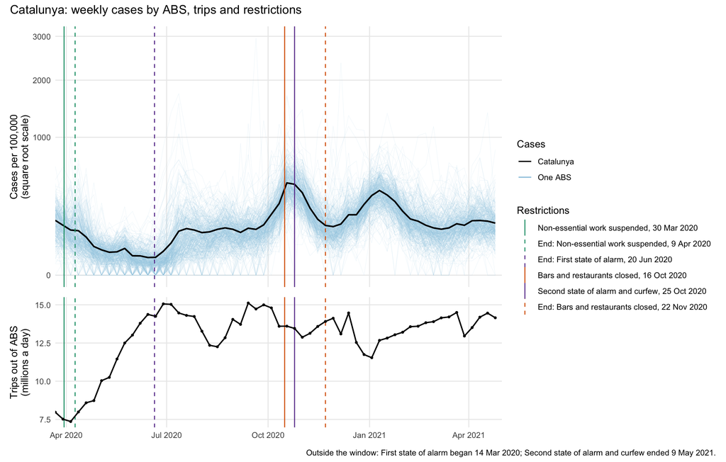

Figure 1: Weekly cases per 100,000 in each ABS and in Catalunya as a whole, with the trips out of all ABS below. Lines mark when each restriction starts (solid) or ends (dashed).

```r
# Colour of each measure
NPI_COL = c(npi_alarm = "#6a3d9a", npi_hibernation = "#1b9e77",
    npi_hospitality = "#d95f02", npi_curfew = "#6a3d9a")

# Day month year, without a leading zero
day = \(x) paste(as.integer(format(x, "%d")), format(x, "%b %Y"))

# Starts and ends inside the study window, one line per date
window = range(dates) + c(0, 6)
events = bind_rows(
        mutate(npi, date = start, type = "start", text = label),
        mutate(npi, date = end, type = "end", text = paste("End:", label))) |>
    filter(date > window[1], date < window[2]) |>
    summarise(text = paste(text, collapse = " and "), measure = measure[1],
        .by = c(date, type)) |>
    mutate(text = paste0(sub(" and Curfew", " and curfew", text), ", ",
        day(date))) |>
    arrange(date) |>
    mutate(text = factor(text, text))

# Starts and ends outside the window, for the caption
outside = bind_rows(mutate(npi, date = start, what = "began"),
        mutate(npi, date = end, what = "ended")) |>
    filter(date < window[1] | date > window[2]) |>
    summarise(text = paste(label, collapse = " and "), .by = c(date, what)) |>
    mutate(text = paste(sub(" and Curfew", " and curfew", text), what,
        day(date)))

# Event lines in one key: colour by measure, solid at starts, dashed at ends
lines = list(
    geom_vline(data = events, aes(xintercept = date, colour = text,
        linetype = text), linewidth = 0.5),
    scale_colour_manual(values = setNames(NPI_COL[events$measure],
        events$text), name = "Restrictions"),
    scale_linetype_manual(values = setNames(ifelse(events$type == "start",
        "solid", "dashed"), events$text), name = "Restrictions"),
    scale_x_date(limits = window, expand = c(0, 0)))

# Weekly cases per 100,000 in Catalunya as a whole: all cases over all residents
regional = data.frame(date = dates, inc = colSums(Y) / sum(popv) * 1e5)

# Weekly incidence by ABS, with Catalunya as a whole
incidence = data.frame(id = rep(ids, 58), date = rep(dates, each = n),
        inc = c(Y) / popv * 1e5) |>
    ggplot(aes(date, inc)) +
    geom_line(aes(group = id, colour = "One ABS"), linewidth = 0.1,
        alpha = 0.3) +
    geom_line(data = regional, aes(colour = "Catalunya"), linewidth = 0.8) +
    scale_colour_manual(values = c(`One ABS` = "#9ecae1",
        Catalunya = "black"), name = "Cases",
        guide = guide_legend(override.aes = list(alpha = 1, linewidth = 0.6))) +
    ggnewscale::new_scale_colour() +
    lines +
    scale_y_sqrt() +
    labs(x = NULL, y = "Cases per 100,000\n(square root scale)") +
    theme(axis.text.x = element_blank())

# Trips out of all ABS
trips_plot = mobility |>
    ggplot(aes(date, trips)) +
    lines +
    geom_line(linewidth = 0.7) +
    geom_point(size = 0.8) +
    labs(x = NULL, y = "Trips out of ABS\n(millions a day)")

# Lowest week of trips, and the range of trips during the two later waves
low = mobility[which.min(mobility$trips), ]
waves = range(filter(mobility, date >= as.Date("2020-09-01"),
    date < as.Date("2021-03-01"))$trips)

# Cases above, trips below, on the same time axis, keys on the side
incidence / trips_plot +
    plot_layout(heights = c(2, 1), guides = "collect") +
    plot_annotation(
        title = "Catalunya: weekly cases by ABS, trips and restrictions",
        caption = paste0("Outside the window: ",
            paste(outside$text, collapse = "; "), "."))
```

Trips fell to 7.4 million a day in the week of 5 Apr 2020, as cases fell under the first state of alarm. The autumn and winter waves came while trips stayed between 11.5 and 15.1 million a day: the volume of trips alone does not track the waves. The trip neighbourhoods test whether where people travel matters instead.

```r
# Weekly cases per 100,000, [week, ABS], in classes up to the highest week
incidence_w = t(Y) / rep(popv, each = 58) * 1e5
CASES_AT = c(0, 50, 100, 200, 400, 800, 13000)
stopifnot(max(incidence_w) < max(CASES_AT))

# One frame: the cases map, and the trips with the week marked
# A weekly series with the restriction lines and the mapped week marked
series = \(x, v, w, label) x |>
    ggplot(aes(date, .data[[v]])) +
    geom_vline(data = events, aes(xintercept = date, colour = measure,
        linetype = type), linewidth = 0.4, show.legend = FALSE) +
    scale_colour_manual(values = NPI_COL) +
    scale_linetype_manual(values = c(start = "solid", end = "dashed")) +
    geom_line(colour = "grey30") +
    geom_point(data = x[w, ], size = 2.5) +
    scale_x_date(limits = window, expand = c(0, 0)) +
    labs(x = NULL, y = label)

frame = \(w) {
    map = abs |>
        mutate(cases = cut(incidence_w[w, ], CASES_AT, include.lowest = TRUE,
            dig.lab = 5)) |>
        ggplot() +
        geom_sf(aes(fill = cases), colour = "white", linewidth = 0.05,
            show.legend = TRUE) +
        scale_fill_brewer(palette = "YlOrRd", drop = FALSE) +
        labs(fill = "Cases per\n100,000") +
        theme_void()
    cases_week = series(regional, "inc", w, "Cases per 100,000\nin Catalunya") +
        theme(axis.text.x = element_blank())
    trips_week = series(mobility, "trips", w,
        "Trips out of ABS\n(millions a day)")
    map / cases_week / trips_week +
        plot_layout(heights = c(3, 1, 1)) +
        plot_annotation(title = paste("Catalunya, week of", day(dates[w])))
}
```

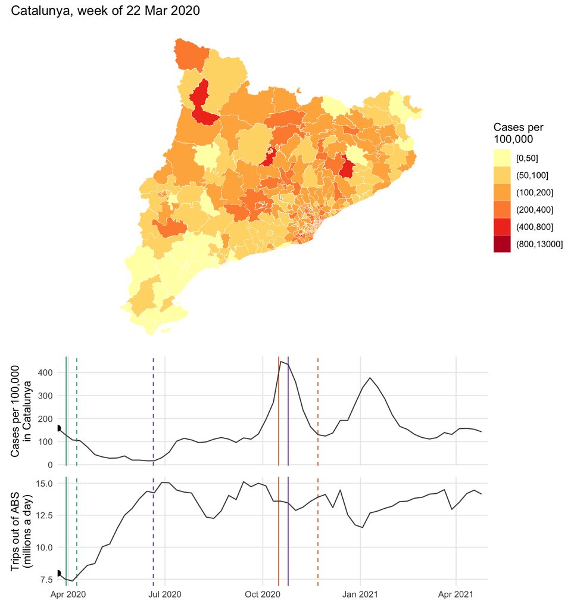

Figure 2: Weekly cases per 100,000 by ABS, one frame per week. Below: cases per 100,000 in Catalunya and trips out of all ABS, with the mapped week marked and the restriction lines of Figure 1.

```r
# One frame per week
for (w in 1:58) print(frame(w))
```

## 2.4 Spatial clustering

Before fitting, we check whether incidence clusters in space, which is what a neighbour component assumes.

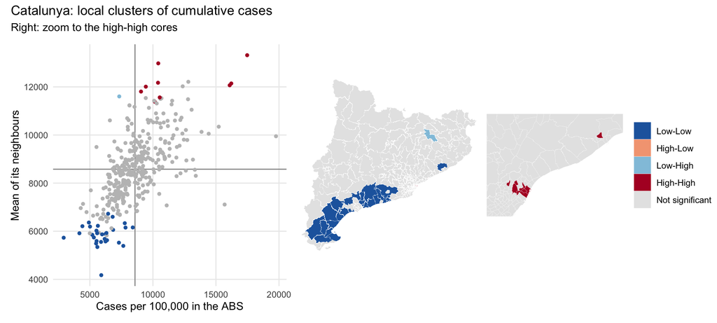

Figure 3: Left: cumulative cases per 100,000 in each ABS against the mean of its neighbours. Grey lines mark the means. Middle and right: local Moran’s I clusters (9,999 permutations, p < 0.05 after false discovery rate adjustment), with a zoom to the high-high cores.

```r
# Local Moran's I of cumulative incidence, row-standardised adjacency weights,
# 9,999 permutations, false discovery rate 5% (Pebesma and Bivand 2023, ch. 15)
cum = rowSums(Y) / popv * 1e5
lw = spdep::mat2listw((a > 0) * 1, style = "W")
local = spdep::localmoran_perm(cum, lw, nsim = 9999, iseed = 1)
cluster = spdep::hotspot(local, Prname = "Pr(z != E(Ii)) Sim", cutoff = 0.05,
    p.adjust = "fdr", droplevels = FALSE)
CLUSTER = c(`High-High` = "#b2182b", `Low-Low` = "#2166ac",
    `High-Low` = "#f4a582", `Low-High` = "#92c5de")

# Moran scatterplot: each ABS against the mean of its neighbours
scatter = data.frame(cum = cum, lag = spdep::lag.listw(lw, cum),
        cluster = cluster) |>
    ggplot(aes(cum, lag, colour = cluster)) +
    geom_vline(xintercept = mean(cum), colour = "grey60") +
    geom_hline(yintercept = mean(cum), colour = "grey60") +
    geom_point(size = 1.2) +
    scale_colour_manual(values = CLUSTER, na.value = "grey75", guide = "none") +
    labs(x = "Cases per 100,000 in the ABS",
        y = "Mean of its neighbours")

# Cluster map, for Catalunya and zoomed to the high-high cores
cluster_map = \(zoom = NULL) abs |>
    mutate(cluster = cluster) |>
    ggplot() +
    geom_sf(aes(fill = cluster), colour = "white", linewidth = 0.05,
        show.legend = TRUE) +
    coord_sf(xlim = zoom[c(1, 3)], ylim = zoom[c(2, 4)]) +
    scale_fill_manual(values = CLUSTER, na.value = "grey90",
        na.translate = TRUE, drop = FALSE,
        labels = \(x) ifelse(is.na(x), "Not significant", x)) +
    labs(fill = NULL) +
    theme_void()
high = abs[which(cluster == "High-High"), ] |>
    st_buffer(3000) |>
    st_bbox()
scatter + cluster_map() + cluster_map(high) +
    plot_layout(widths = c(1.2, 1, 0.7), guides = "collect") +
    plot_annotation(title = "Catalunya: local clusters of cumulative cases",
        subtitle = "Right: zoom to the high-high cores")
```

Cumulative incidence clusters between adjacent ABS: global Moran’s I is 0.46. Local Moran’s I (Pebesma and Bivand 2023) finds 9 high-high and 29 low-low cores, ABS whose incidence and that of their neighbours are both above or both below the mean. The high-high cores are Barcelona - 09E, Mataró - 5, Santa Coloma de Gramenet - 4, Badalona - 04, Badalona - 05, Badalona - 06, Sant Adrià de Besòs - 1, Barcelona - 08I, Badalona - 07B. The low-low cores lie mostly along the southern coast, from the Penedès and the Garraf to the Ebre delta.

# 3 Neighbourhoods

The three models differ only in the neighbour weights $w_{ji}$. The weights split the cases of each source ABS $j$ across the ABS $i$ it is linked to, so the weights from each source sum to 1.

| Version | How the weights fall | Question it answers |
| --- | --- | --- |
| Boundaries | With the number of borders crossed, at an estimated rate | Does adjacency describe how cases spread between ABS? |
| Trip orders | With the rank of each destination by trips, in rings of the same size as by boundaries, at an estimated rate | Are the ABS people travel to most better neighbours than the adjacent ones? |
| Trip shares | In proportion to the share of trips to each destination, with no rate to estimate | Does the volume of trips describe spread between ABS without a distance rule? |

- **Boundaries**: ABS that touch at a single point count as sharing a border (queen adjacency).
- **Trip orders**: each ABS’s destinations are ranked by their mean daily trips over the whole period. The destinations with most trips take order 1, the next take order 2 and then order 3, with as many ABS at each order as by boundaries. Only which ABS count as close changes, which makes the comparison with boundaries a fair test of who the neighbours are.
- **Trip shares**: if 10% of the trips leaving ABS $j$ end in ABS $i$, then 10% of $j$’s neighbour weight goes to $i$. Every ABS that receives trips from $j$ is a neighbour.

## 3.1 Create neighbourhoods

```r
# Boundary order, [from, to]
geo = nbOrder((a > 0) * 1, maxlag = Inf)
dimnames(geo) = list(ids, ids)

# Number of ABS at each boundary order by origin, orders above 3 as 4
size = geo |>
    apply(1, \(o) tabulate(pmin(o[o > 0], 4), 4)) |>
    t()
stopifnot(rowSums(size) == n - 1)

# Trip order, [from, to]
mob = matrix(0L, n, n, dimnames = list(ids, ids))
for (j in 1:n) {
    rank = order(trips[j, -j], decreasing = TRUE)
    mob[j, -j][rank] = rep(1:4, size[j, ])
}
stopifnot(rowSums(mob == 1) == rowSums(geo == 1))


# Trip shares, [from, to], each row sums to 1
share = trips / rowSums(trips)
stopifnot(all.equal(unname(rowSums(share)), rep(1, n)))
```

## 3.2 Stability of trip orders across restriction phases

The restrictions split the period into phases, runs of days with the same measures in force. Trip orders built from each phase’s trips show whether people’s destinations changed with the restrictions.

```r
# Restriction phase of each day: the measures in force, in words
MEASURE = c(npi_alarm = "state of alarm",
    npi_hibernation = "non-essential work suspended", npi_curfew = "curfew",
    npi_hospitality = "bars and restaurants closed")
days_npi = panel |>
    filter(id == ids[1]) |>
    arrange(date)
in_force = as.matrix(days_npi[names(MEASURE)]) == 1
phase_name = apply(in_force, 1, \(x) if (any(x)) paste(MEASURE[x],
    collapse = ", ") else "no restriction")
phases = unique(phase_name)
phase = match(phase_name, phases)

# Mean daily trips between ABS in each phase, [origin, destination, phase]
index = \(v) setNames(data.frame(ids, seq_len(n)), c(v, paste0(v, "_i")))
flows = spain("data/cat_od_bha_reprojected") |>
    arrow::open_dataset() |>
    inner_join(index("source"), by = "source") |>
    inner_join(index("target"), by = "target") |>
    inner_join(data.frame(date = d$dates, phase = phase), by = "date") |>
    group_by(source_i, target_i, phase) |>
    summarise(trips = sum(trips)) |>
    collect()
trips_phase = array(0, c(n, n, length(phases)))
trips_phase[cbind(flows$source_i, flows$target_i, flows$phase)] = flows$trips
trips_phase = sweep(trips_phase, 3, tabulate(phase), "/")

# Trip orders of each phase, and the share of neighbours they keep
trip_orders = \(x) {
    diag(x) = 0
    m = matrix(0L, n, n, dimnames = list(ids, ids))
    for (j in 1:n) {
        rank = order(x[j, -j], decreasing = TRUE)
        m[j, -j][rank] = rep(1:4, size[j, ])
    }
    m
}
same_order = \(x, y, k, rows = 1:n) mean(sapply(rows, \(j) {
    g = x[j, ] == k
    if (any(g)) mean(y[j, g] == k) else NA
}), na.rm = TRUE)
phase_orders = lapply(seq_along(phases), \(p) trip_orders(trips_phase[, , p]))
stability = data.frame(Phase = sub("^(.)", "\\U\\1", phases, perl = TRUE),
    Days = tabulate(phase),
    t(sapply(phase_orders, \(m) round(100 * sapply(1:3, same_order, x = mob,
        y = m)))))
names(stability)[3:5] = paste0("Order ", 1:3, " (%)")
knitr::kable(stability)
```

| Phase | Days | Order 1 (%) | Order 2 (%) | Order 3 (%) |
| --- | --- | --- | --- | --- |
| State of alarm | 80 | 96 | 93 | 87 |
| State of alarm, non-essential work suspended | 11 | 93 | 87 | 74 |
| No restriction | 117 | 98 | 96 | 91 |
| Bars and restaurants closed | 9 | 97 | 93 | 87 |
| State of alarm, curfew, bars and restaurants closed | 29 | 97 | 95 | 90 |
| State of alarm, curfew | 160 | 98 | 96 | 93 |

The table gives the share of an ABS’s neighbours at each order that are the same in a phase as over the whole period. An ABS’s most-visited destinations hardly change: 93% to 98% of order-1 neighbours stay the same in every phase, the lowest when non-essential work was suspended. One matrix for the whole period is therefore a fair summary, and weights that switch with the phase do not improve the fit (Section 5.1.2).

## 3.3 Urban and rural ABS

```r
# Population density terciles
area = read.csv(spain("outputs/catalunya/tables/cat_abs_areas.csv"),
    colClasses = c(id = "character"))
density = popv / area$area_km2[match(ids, area$id)]
setting = cut(density, quantile(density, 0:3 / 3), include.lowest = TRUE,
    labels = c("Rural", "Middle", "Urban"))

# Trip neighbours that are also boundary neighbours, and the trips they take
order1_trips = sapply(1:n, \(j) sum(trips[j, mob[j, ] == 1]) / sum(trips[j, ]))
urban_rural = data.frame(Setting = levels(setting),
        `People per km² (median)` = round(tapply(density, setting, median)),
        `Order-1 trip neighbours also adjacent (%)` = sapply(levels(setting),
            \(s) round(100 * same_order(mob, geo, 1, which(setting == s)))),
        `Trips to order-1 trip neighbours (%)` = round(100 *
            tapply(order1_trips, setting, mean)), check.names = FALSE)
knitr::kable(urban_rural, row.names = FALSE)
```

| Setting | People per km² (median) | Order-1 trip neighbours also adjacent (%) | Trips to order-1 trip neighbours (%) |
| --- | --- | --- | --- |
| Rural | 74 | 72 | 66 |
| Middle | 1712 | 71 | 58 |
| Urban | 22574 | 57 | 38 |

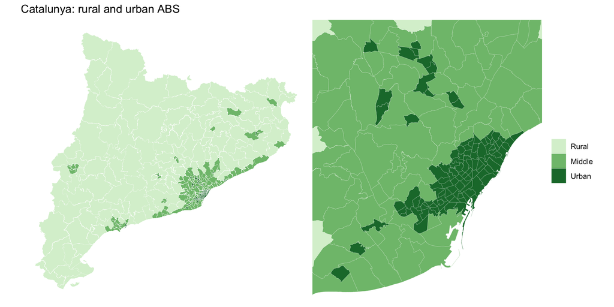

Figure 4: ABS by population density: the third with the lowest density (rural), the middle third and the third with the highest (urban). Right: zoom to the Barcelona area, where most urban ABS lie.

```r
# Density terciles on the map, darker for denser, with a zoom to the urban ABS
setting_map = \(zoom = NULL) abs |>
    mutate(setting = setting) |>
    ggplot() +
    geom_sf(aes(fill = setting), colour = "white", linewidth = 0.05) +
    coord_sf(xlim = zoom[c(1, 3)], ylim = zoom[c(2, 4)]) +
    scale_fill_manual(values = c(Rural = "#d9f0d3", Middle = "#7fbf7b",
        Urban = "#1b7837")) +
    labs(fill = NULL) +
    theme_void()
# Zoom: the urban ABS within 20 km of Barcelona city
barcelona = abs[startsWith(abs$name, "Barcelona - "), ] |>
    st_union() |>
    st_centroid()
urban = abs[setting == "Urban", ]
urban = urban[as.numeric(st_distance(urban, barcelona)) < 20000, ] |>
    st_buffer(1000) |>
    st_bbox()
setting_map() + setting_map(urban) +
    plot_layout(guides = "collect") +
    plot_annotation(title = "Catalunya: rural and urban ABS")
```

Boundaries and trips disagree most in urban ABS. Rural ABS send most of their trips to a few destinations, mostly adjacent ones. Urban ABS spread their trips over many destinations, and fewer of their closest trip neighbours share a border with them.

## 3.4 Overlap of boundary and trip orders

```r
# Share of an ABS's boundary neighbours at order k that are trip neighbours
same = \(j, k) {
    g = geo[j, ] == k
    if (any(g)) sum(g & mob[j, ] == k) / sum(g) else NA
}
overlap = sapply(1:3, \(k) mean(sapply(1:n, same, k = k), na.rm = TRUE))
data.frame(Order = 1:3, `Same neighbours (%)` = round(100 * overlap),
        check.names = FALSE) |>
    knitr::kable()
```

| Order | Same neighbours (%) |
| --- | --- |
| 1 | 66 |
| 2 | 52 |
| 3 | 39 |

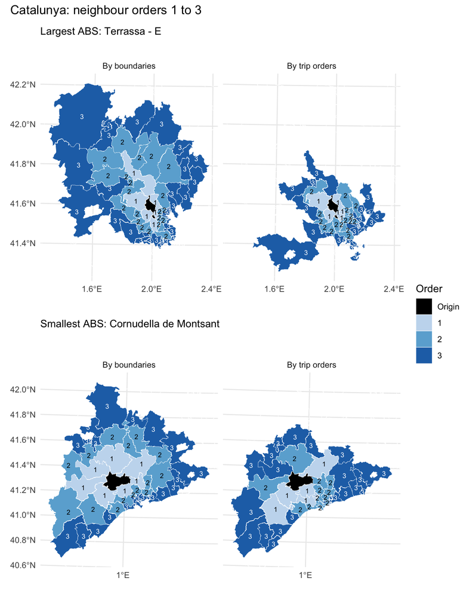

Figure 5: Order-1 to order-3 neighbours of the largest and the smallest ABS, by boundaries and by trip orders. Darker: higher order.

```r
# Orders 1 to 3 around the largest and the smallest ABS
pick = c(`Largest ABS` = ids[which.max(popv)],
    `Smallest ABS` = ids[which.min(popv)])
ring = \(o, j) factor(ifelse(ids == j, "Origin", ifelse(o <= 3, o, NA)),
    names(ORDER))

# One row per origin: orders by boundaries and by trips, zoomed alike
map_orders = \(label, j) {
    x = bind_rows(
        mutate(abs, by = "By boundaries", order = ring(geo[j, ], j)),
        mutate(abs, by = "By trip orders", order = ring(mob[j, ], j)))
    zoom = x |>
        filter(!is.na(order)) |>
        st_bbox()
    ggplot(x) +
        geom_sf(aes(fill = order), colour = "white", linewidth = 0.1) +
        geom_sf_text(data = filter(x, order %in% 1:3),
            aes(label = order, colour = order == 3), size = 2.5,
            check_overlap = TRUE) +
        facet_wrap(~by) +
        coord_sf(datum = st_crs(4326), xlim = zoom[c(1, 3)],
            ylim = zoom[c(2, 4)]) +
        scale_x_continuous(n.breaks = 3) +
        scale_fill_manual(values = ORDER, na.value = "grey92",
            na.translate = FALSE, drop = FALSE) +
        scale_colour_manual(values = c(`TRUE` = "white", `FALSE` = "black"),
            guide = "none") +
        labs(subtitle = paste0(label, ": ", abs$name[abs$id == j]),
            x = NULL, y = NULL, fill = "Order")
}
Map(map_orders, names(pick), pick) |>
    wrap_plots(ncol = 1, guides = "collect") +
    plot_annotation(title = "Catalunya: neighbour orders 1 to 3")
```

# 4 Model

The model for the cases $Y_{it}$ in ABS $i$ in week $t$:

$$\begin{aligned}
Y_{it} \mid Y_{\cdot,\,t-1} &\sim \operatorname{NegBin}(\mu_{it},\ \psi), \quad \operatorname{Var} = \mu_{it}(1 + \psi\,\mu_{it}) \\[4pt]
\mu_{it} &= \underbrace{e_i\,\nu_t}_{\text{endemic}}
+ \underbrace{\lambda\,Y_{i,t-1}}_{\text{autoregressive}}
+ \underbrace{\phi_i \sum_{j \ne i} w_{ji}\,Y_{j,t-1}}_{\text{neighbour}} \\[4pt]
e_i &= \text{population share of ABS } i \\[4pt]
\log \nu_t &= \alpha_\nu + \beta \underbrace{t}_{0 \text{ in week 1}} \\[4pt]
\log \phi_i &= \alpha_\phi + \tau \underbrace{\log N_i}_{N_i = \text{population of ABS } i \text{, centred}} \\[4pt]
w_{ji} &= \frac{o_{ji}^{-d}}{\sum_{k:\, o_{jk} \le 3} o_{jk}^{-d}} \text{ for } \underbrace{o_{ji}}_{\text{order of } i \text{ from } j} \le 3,
\text{ and 0 beyond} \quad \text{(boundaries, trip orders)} \\[4pt]
w_{ji} &= \frac{F_{ji}}{\sum_{k \ne j} F_{jk}}, \quad \underbrace{F_{ji}}_{\text{mean daily trips from } j \text{ to } i} \quad \text{(trip shares)}
\end{aligned}$$

The power-law weights follow Meyer and Held (2014), with neighbours up to order 3: beyond it, the weight of each ABS pair is small. The parameters are estimated by maximum likelihood (Meyer et al. 2017). The first week only provides the lagged cases, so the models are fitted to weeks 2 to 58.

## 4.1 Covariates

Each model is also fitted with temperature and restrictions in the autoregressive and neighbour components:

$$\log \lambda_{it} = \alpha_\lambda + \boldsymbol{\gamma}^\top \mathbf{x}_{it}, \qquad
\log \phi_{it} = \alpha_\phi + \tau \log N_i + \boldsymbol{\delta}^\top \mathbf{x}_{it}$$

The covariates $\mathbf{x}_{it}$ are weekly values:

- **Temperature**: the mean daily temperature in the ABS, centred and per 5 °C.
- **State of alarm**, **non-essential work suspended** and **bars and restaurants closed**: the share of days in the week with the measure in force.

The curfew is left out: in Catalunya it ran on the same days as the second state of alarm. The effects $e^{\gamma}$ and $e^{\delta}$ are rate ratios. For temperature, they compare weeks 5 °C apart. For a restriction, they compare a week with the measure in force on all seven days with a week without it. They describe associations with the weekly cases, not the effect of a measure, and they act on the cases that follow from past cases, not on trips.

## 4.2 Model fitting

```r
# Population matrix, [week, ABS]
pop = matrix(popv, 58, n, byrow = TRUE, dimnames = list(NULL, ids))

# One sts object for each neighbourhood
make_sts = \(nb) sts(observed = t(Y), start = c(2020, 13), frequency = 52,
    population = pop / sum(popv), neighbourhood = nb)
sts_geo = make_sts(geo)
sts_mob = make_sts(mob)

# Shared model, with the neighbour weights set for each version
model = list(
    end = list(f = ~1 + t, offset = population(sts_geo)),
    ar = list(f = ~1),
    ne = list(f = ~1 + logpop, weights = W_powerlaw(maxlag = 3)),
    family = "NegBin1",
    data = list(logpop = log(pop) - mean(log(popv))),
    subset = 2:58)
shares_model = modifyList(model, list(ne = list(weights = share)))

# Fit all three
fits = list(
    Boundaries = hhh4(sts_geo, model),
    `Trip orders` = hhh4(sts_mob, model),
    `Trip shares` = hhh4(sts_geo, shares_model))
stopifnot(sapply(fits, \(f) f$convergence),
    lengths(lapply(fits, coef)) == c(7, 7, 6))
```

```r
# Weekly covariates, [week, ABS]
covariates = list(
    temp = (weekly("temp_mean") - mean(weekly("temp_mean"))) / 5,
    alarm = weekly("npi_alarm"),
    work = weekly("npi_hibernation"),
    bars = weekly("npi_hospitality"))
stopifnot(all(sapply(covariates, dim) == c(58, n)))

# Same three models with the covariates in both epidemic components
with_covariates = \(m) modifyList(m, list(
    ar = list(f = ~1 + temp + alarm + work + bars),
    ne = list(f = ~1 + logpop + temp + alarm + work + bars),
    data = c(m$data, covariates)))
fits_cov = list(
    Boundaries = hhh4(sts_geo, with_covariates(model)),
    `Trip orders` = hhh4(sts_mob, with_covariates(model)),
    `Trip shares` = hhh4(sts_geo, with_covariates(shares_model)))
stopifnot(sapply(fits_cov, \(f) f$convergence))
```

# 5 Results

## 5.1 Which neighbourhood fits best

### 5.1.1 In-sample fit

AIC weighs how well a model fits against how many parameters it uses: lower is better, and a difference of more than about 10 is clear. The two power-law models have seven parameters and the trip-share model six.

```r
# Compare
cmp = fits |>
    sapply(diagnostics) |>
    t()
best = names(fits)[which.min(cmp[, "AIC"])]

# The conclusions below are written for boundaries fitting best
stopifnot(best == "Boundaries")
cmp |>
    as.data.frame() |>
    mutate(Model = rownames(cmp), .before = 1) |>
    mutate(`AIC - best` = AIC - min(AIC), .after = AIC) |>
    arrange(AIC) |>
    knitr::kable(digits = c(0, 0, 0, 0, 2), row.names = FALSE)
```

| Model | AIC | AIC - best | logLik | RMSE |
| --- | --- | --- | --- | --- |
| Boundaries | 158762 | 0 | -79374 | 17.46 |
| Trip shares | 158986 | 224 | -79487 | 17.59 |
| Trip orders | 159112 | 350 | -79549 | 17.75 |

### 5.1.2 Trip neighbours by restriction phase

Weights that switch with the restriction phase of each week, against one matrix for the whole period. For trip orders, the decay is profiled over a grid and counted as one parameter.

```r
# Phase of each week: the phase of most of its days
week_phase = sapply(split(phase, week),
    \(p) as.integer(names(which.max(table(p)))))
by_week = \(f) {
    x = array(0, c(n, n, 58))
    for (w in 1:58) x[, , w] = f(week_phase[w])
    x
}
fit_weights = \(W) hhh4(sts_geo,
    modifyList(model, list(ne = list(weights = W))))
row_norm = \(m) m / rowSums(m)
powerlaw = \(o, dd) row_norm(ifelse(o >= 1 & o <= 3, pmax(o, 1)^-dd, 0))

# Trip shares by phase
shares_phase = by_week(\(p) row_norm(`diag<-`(trips_phase[, , p], 0))) |>
    fit_weights()

# Trip orders by phase, decay profiled
grid = seq(0.4, 3, by = 0.1)
profile = sapply(grid, \(dd) {
    P = lapply(phase_orders, powerlaw, dd = dd)
    as.numeric(logLik(fit_weights(by_week(\(p) P[[p]]))))
})
data.frame(Neighbours = c("Trip shares", "Trip orders"),
        `One matrix` = sapply(fits[c("Trip shares", "Trip orders")], AIC),
        `By phase` = c(AIC(shares_phase), -2 * max(profile) + 2 * 7),
        check.names = FALSE) |>
    knitr::kable(digits = 0, row.names = FALSE)
```

| Neighbours | One matrix | By phase |
| --- | --- | --- |
| Trip shares | 158986 | 159006 |
| Trip orders | 159112 | 159140 |

### 5.1.3 One-week-ahead forecasts

Each of the last 20 weeks is forecast from a refit to the weeks before it (Meyer and Held 2014). Lower scores are better. The permutation test compares each trip model’s logarithmic scores with those of the boundary model.

```r
# Fit to week tp, predict week tp + 1, for the last 20 weeks
osa = lapply(fits, oneStepAhead, tp = c(38, 57), type = "rolling",
    which.start = "final", verbose = FALSE)
sc = lapply(osa, scores, which = c("logs", "rps", "dss"), individual = TRUE,
    reverse = FALSE)
stopifnot(sapply(sc, \(s) dim(s)[1]) == 20)

# Permutation tests of the logarithmic scores against boundaries
p_logs = sapply(names(fits)[-1], \(k) permutationTest(sc[[k]][, , "logs"],
    sc$Boundaries[, , "logs"], nPermutation = 999, verbose = FALSE)$pVal.permut)

# Mean scores
sc |>
    sapply(\(s) colMeans(s, dims = 2)) |>
    t() |>
    as.data.frame() |>
    mutate(p = c("", sprintf("%.3f", p_logs))) |>
    knitr::kable(digits = 4, col.names = c("Logarithmic",
        "Ranked probability", "Dawid-Sebastiani", "p (logarithmic)"))
```

|  | Logarithmic | Ranked probability | Dawid-Sebastiani | p (logarithmic) |
| --- | --- | --- | --- | --- |
| Boundaries | 4.0916 | 9.4055 | 6.5911 |  |
| Trip orders | 4.1031 | 9.5564 | 6.6205 | 0.001 |
| Trip shares | 4.0989 | 9.5081 | 6.6194 | 0.001 |

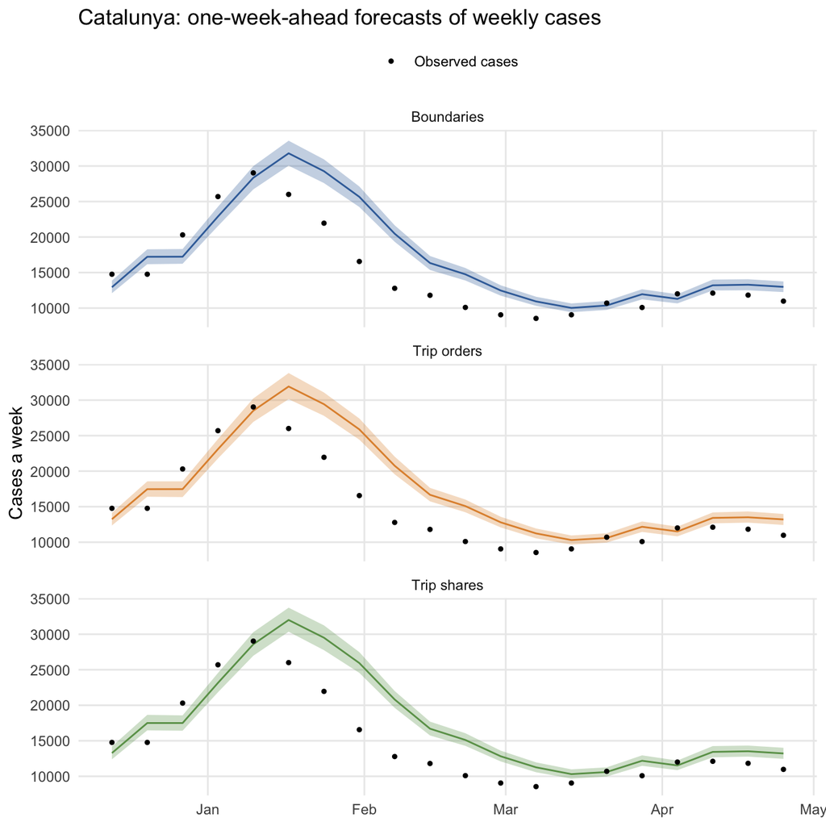

Figure 6: Weekly cases in Catalunya over the last 20 weeks: observed (points) and one-week-ahead forecast mean (line). Band: 95% interval for the count variation alone.

```r
# Weekly cases in Catalunya: predicted mean and 95% interval from 2,000 draws
set.seed(1)
interval = \(o) {
    draws = sapply(seq_len(nrow(o$pred)), \(w) colSums(matrix(rnbinom(n * 2000,
        mu = o$pred[w, ], size = exp(o$psi[w, 1])), n)))
    data.frame(date = dates[as.integer(rownames(o$pred))],
        mean = rowSums(o$pred), lo = apply(draws, 2, quantile, 0.025),
        hi = apply(draws, 2, quantile, 0.975), observed = rowSums(o$observed))
}
predictions = osa |>
    lapply(interval) |>
    bind_rows(.id = "model")

# Lag of the boundary model's predictions around the observed peak
lag = predictions |>
    filter(model == "Boundaries") |>
    mutate(after = date > date[which.max(observed)])
peak_obs = lag[which.max(lag$observed), ]
peak_pred = lag[which.max(lag$mean), ]
lag_weeks = as.integer(peak_pred$date - peak_obs$date) / 7
rise = filter(lag, date < peak_obs$date)
fall = filter(lag, after)
below = c(sum(rise$mean < rise$observed), nrow(rise))
above = c(sum(fall$mean > fall$observed), nrow(fall))

# Predicted against observed, one panel per model
predictions |>
    ggplot(aes(date)) +
    geom_ribbon(aes(ymin = lo, ymax = hi, fill = model), alpha = 0.3) +
    geom_line(aes(y = mean, colour = model)) +
    geom_point(aes(y = observed, shape = "Observed cases"), size = 1.2) +
    facet_wrap(~model, ncol = 1) +
    scale_colour_manual(values = MODEL, aesthetics = c("colour", "fill"),
        guide = "none") +
    scale_shape_manual(values = 16) +
    labs(title = "Catalunya: one-week-ahead forecasts of weekly cases",
        x = NULL, y = "Cases a week", shape = NULL) +
    theme(legend.position = "top")
```

All three models react to the turning point of the winter wave a week late. Cases peaked at 29,030 in the week of 10 Jan 2021, and the boundary model’s forecasts peaked 1 week later, at 31,789. The forecasts run below the observed cases in 3 of 4 weeks before the peak and above them in 13 of 15 weeks after it, as each week is forecast largely from the week before.

As regional totals, the three forecasts are almost the same: the neighbourhood matters for where cases occur rather than for how many. The band leaves out parameter uncertainty and the correlation between ABS, so it is narrower than the full uncertainty.

## 5.2 Parameters and neighbour weights

Estimates with 95% Wald intervals, computed on the log scale for the rates, the trend and ψ.

```r
# Coefficients reported as exp(estimate)
EXP = c("ar.1", "ne.1", "end.1", "end.t")
LABEL = c(ar.1 = "Autoregressive rate λ",
    ne.1 = "Neighbour rate φ, ABS of geometric-mean population, exp(α_φ)",
    ne.logpop = "Population exponent τ",
    end.1 = "Endemic cases a week, all ABS, week 1, exp(α_ν)",
    end.t = "Endemic trend per week, exp(β)",
    neweights.d = "Decay d",
    overdisp = "Overdispersion ψ")

# Estimate (95% interval) by coefficient name, and the dominant eigenvalue
estimates = \(f) {
    x = wald(f, EXP)
    x = setNames(sprintf("%.3f (%.3f to %.3f)", x[, 1], x[, 2], x[, 3]),
        rownames(x))
    c(x[names(LABEL)], `Dominant eigenvalue` = sprintf("%.2f", getMaxEV(f)[1]))
}
table = sapply(fits, estimates)
table[is.na(table)] = ""
rownames(table) = c(LABEL, "Dominant eigenvalue")
knitr::kable(table)
```

|  | Boundaries | Trip orders | Trip shares |
| --- | --- | --- | --- |
| Autoregressive rate λ | 0.631 (0.616 to 0.645) | 0.669 (0.655 to 0.684) | 0.635 (0.621 to 0.650) |
| Neighbour rate φ, ABS of geometric-mean population, exp(α_φ) | 0.263 (0.250 to 0.276) | 0.231 (0.218 to 0.245) | 0.270 (0.256 to 0.285) |
| Population exponent τ | 0.692 (0.647 to 0.736) | 0.304 (0.255 to 0.353) | 0.177 (0.130 to 0.224) |
| Endemic cases a week, all ABS, week 1, exp(α_ν) | 383.946 (351.790 to 419.042) | 424.339 (391.159 to 460.333) | 407.872 (375.209 to 443.379) |
| Endemic trend per week, exp(β) | 1.030 (1.027 to 1.032) | 1.030 (1.028 to 1.032) | 1.030 (1.028 to 1.033) |
| Decay d | 1.613 (1.427 to 1.800) | 1.226 (1.060 to 1.391) |  |
| Overdispersion ψ | 0.231 (0.226 to 0.237) | 0.237 (0.231 to 0.243) | 0.234 (0.228 to 0.240) |
| Dominant eigenvalue | 0.94 | 0.92 | 0.92 |

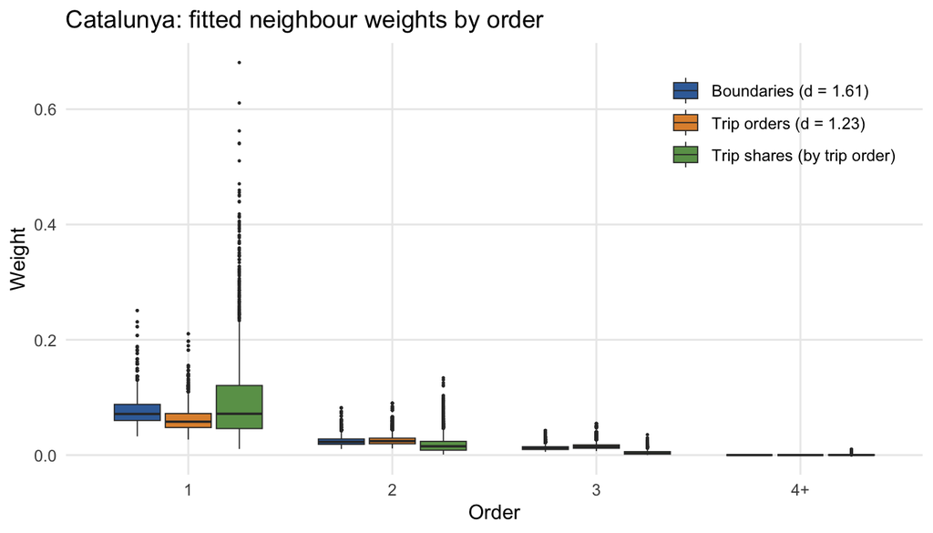

Figure 7: Fitted weight of every ABS pair by order. Each ABS’s weights sum to 1. Trip shares are grouped by trip order.

```r
# Decay of the two power-law models
decay = fits[c("Boundaries", "Trip orders")] |>
    sapply(\(f) coef(f, se = TRUE)["neweights.d", ]) |>
    t()

# Fitted weight of every ABS pair by order, trip shares by trip order
weights = Map(\(f, o) data.frame(order = c(o), w = c(getNEweights(f))),
        fits, list(geo, mob, mob)) |>
    bind_rows(.id = "model") |>
    filter(order > 0) |>
    mutate(order = factor(pmin(order, 4), 1:4, c(1:3, "4+")))

# Mean share of each ABS's outgoing weight on its order-1 neighbours
w1 = Map(\(f, o) mean(rowSums(getNEweights(f) * (o == 1))), fits,
    list(geo, mob, mob)) |>
    unlist()

# Weights by order, one box per model
weights |>
    ggplot(aes(order, w, fill = model)) +
    geom_boxplot(outlier.size = 0.2, linewidth = 0.3) +
    scale_fill_manual(values = MODEL, labels = c(sprintf("%s (d = %.2f)",
        rownames(decay), decay[, 1]), "Trip shares (by trip order)")) +
    labs(title = "Catalunya: fitted neighbour weights by order",
        x = "Order", y = "Weight", fill = NULL) +
    theme(legend.position = "inside", legend.position.inside = c(0.98, 0.95),
        legend.justification.inside = c(1, 1))
```

On average, order-1 neighbours receive 43% of an ABS’s neighbour weight by boundaries and 35% by trip orders. With trip shares, the same number of top destinations receive 54%. The neighbour component works mainly through the few ABS closest by each definition.

## 5.3 How the fitted cases split

### 5.3.1 Over time

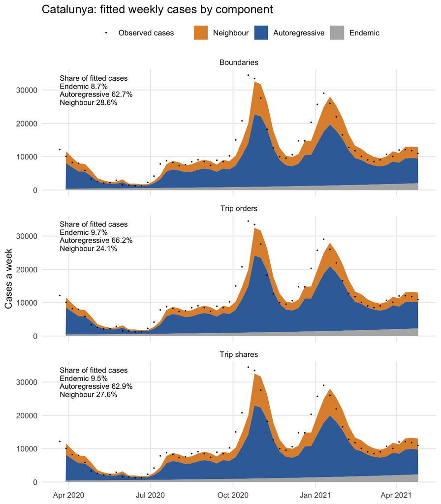

Figure 8: Fitted weekly cases in Catalunya by component, with the observed cases and each component’s share of all fitted cases.

```r
# Share of all fitted cases by component
cs = lapply(fits, components)
shares = cs |>
    sapply(\(m) 100 * sapply(m[names(COMPONENT)], sum) / sum(m$mean)) |>
    t()

# Observed cases and the share labels
observed_total = data.frame(date = dates, cases = colSums(Y))
share_label = data.frame(model = rownames(shares), date = dates[1],
    label = sprintf(paste0("Share of fitted cases\nEndemic %.1f%%\n",
        "Autoregressive %.1f%%\nNeighbour %.1f%%"),
        shares[, "Endemic"], shares[, "Autoregressive"],
        shares[, "Neighbour"]))

# Fitted weekly cases by component, one panel per model
cs |>
    lapply(long) |>
    bind_rows(.id = "model") |>
    summarise(cases = sum(cases), .by = c(model, date, component)) |>
    ggplot(aes(date, cases)) +
    geom_area(aes(fill = component)) +
    geom_point(data = observed_total, aes(shape = "Observed cases"),
        size = 0.5) +
    geom_text(data = share_label, aes(label = label), y = Inf, hjust = 0,
        vjust = 1.2, size = 3, lineheight = 0.9) +
    facet_wrap(~model, ncol = 1) +
    scale_fill_manual(values = COMPONENT) +
    scale_shape_manual(values = 16) +
    labs(title = "Catalunya: fitted weekly cases by component",
        x = NULL, y = "Cases a week", fill = NULL, shape = NULL) +
    theme(legend.position = "top")
```

### 5.3.2 Neighbour share across ABS

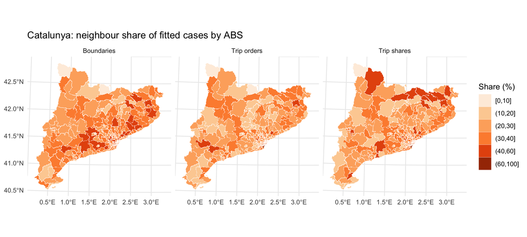

Figure 9: Share of each ABS’s fitted cases from the neighbour component.

```r
# Neighbour share of each ABS's fitted cases, on shared classes
neighbour_share = \(m) 100 * colSums(m$Neighbour) / colSums(m$mean)
cs |>
    lapply(\(m) mutate(abs, share = neighbour_share(m))) |>
    bind_rows(.id = "model") |>
    mutate(share = cut(share, c(0, 10, 20, 30, 40, 60, 100),
        include.lowest = TRUE)) |>
    ggplot() +
    geom_sf(aes(fill = share), colour = "white", linewidth = 0.05) +
    facet_wrap(~model) +
    LONLAT +
    scale_fill_brewer(palette = "Oranges", drop = FALSE) +
    labs(title = "Catalunya: neighbour share of fitted cases by ABS",
        fill = "Share (%)")
```

### 5.3.3 The four ABS with most cases

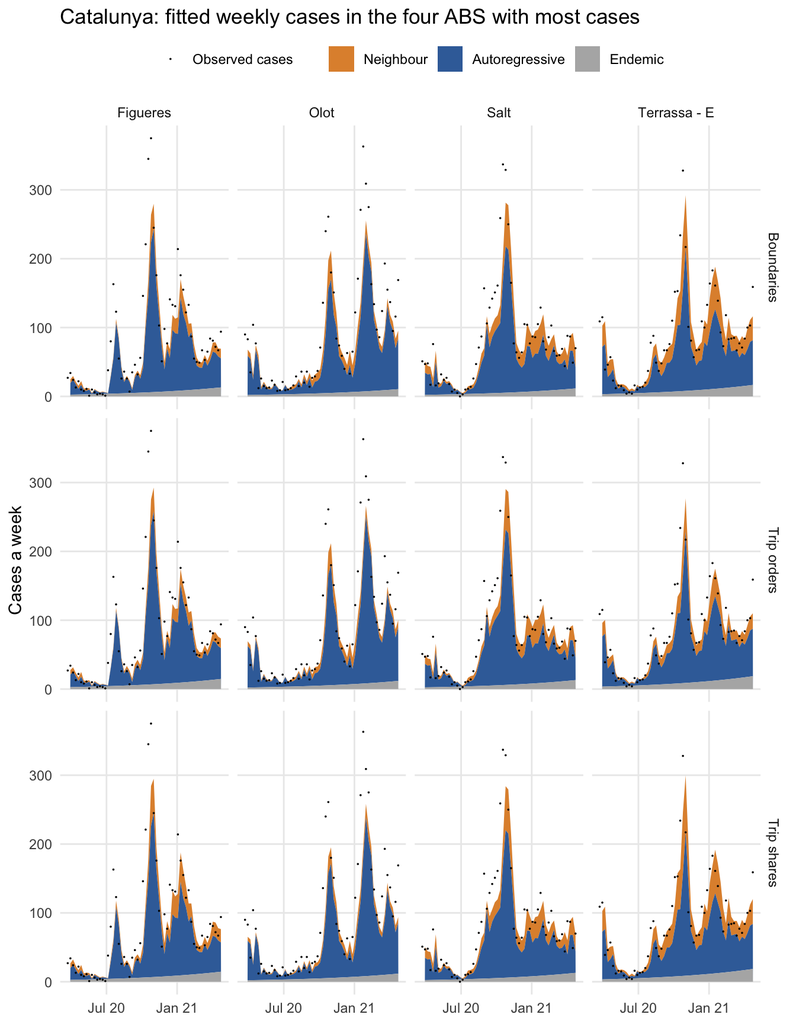

Figure 10: Fitted weekly cases by component in the four ABS with most cases, one row per model, with the observed cases.

```r
# Four ABS with most cases
top = order(rowSums(Y), decreasing = TRUE)[1:4]
observed_top = data.frame(date = rep(dates, 4),
    abs = rep(abs$name[top], each = 58), cases = c(t(Y[top, ])))

# Fitted components, one row per model
cs |>
    lapply(long, cols = top) |>
    bind_rows(.id = "model") |>
    ggplot(aes(date, cases)) +
    geom_area(aes(fill = component)) +
    geom_point(data = observed_top, aes(shape = "Observed cases"),
        size = 0.3) +
    facet_grid(model ~ abs) +
    scale_x_date(breaks = as.Date(c("2020-07-01", "2021-01-01")),
        date_labels = "%b %y") +
    scale_fill_manual(values = COMPONENT) +
    scale_shape_manual(values = 16) +
    labs(title = paste("Catalunya: fitted weekly cases in the four ABS",
        "with most cases"),
        x = NULL, y = "Cases a week", fill = NULL, shape = NULL) +
    theme(legend.position = "top")
```

## 5.4 Temperature and restrictions

```r
# AIC with and without covariates
gain = sapply(fits, AIC) - sapply(fits_cov, AIC)
best_cov = names(fits_cov)[which.min(sapply(fits_cov, AIC))]
data.frame(Model = names(fits), `AIC without` = sapply(fits, AIC),
        `AIC with covariates` = sapply(fits_cov, AIC), check.names = FALSE) |>
    mutate(`AIC with - best` = `AIC with covariates` -
        min(`AIC with covariates`)) |>
    knitr::kable(digits = 0, row.names = FALSE)
```

| Model | AIC without | AIC with covariates | AIC with - best |
| --- | --- | --- | --- |
| Boundaries | 158762 | 156691 | 0 |
| Trip orders | 159112 | 156998 | 307 |
| Trip shares | 158986 | 156907 | 216 |

```r
# Rate ratios with 95% intervals, by component and model
COVARIATE = c(temp = "Temperature (per 5 °C)", alarm = "State of alarm",
    work = "Non-essential work suspended", bars = "Bars and restaurants closed")
rows = paste0(rep(c("ar.", "ne."), each = 4), names(COVARIATE))
rate_ratios = \(f) {
    x = wald(f, rows)[rows, ]
    setNames(sprintf("%.2f (%.2f to %.2f)", x[, 1], x[, 2], x[, 3]), rows)
}
# One association in words, for the boundary model
say = \(r, rate) {
    x = wald(fits_cov$Boundaries, rows)[r, ]
    ci = sprintf("(%.2f, %.2f to %.2f)", x[1], x[2], x[3])
    if (x[2] <= 1 && x[3] >= 1) paste(rate, "no clear change", ci)
    else sprintf("%s %d%% %s %s", rate, round(100 * abs(1 - x[1])),
        if (x[1] < 1) "lower" else "higher", ci)
}
fits_cov |>
    sapply(\(f) rate_ratios(f)[rows]) |>
    `rownames<-`(paste0(rep(c("Autoregressive λ: ", "Neighbour φ: "),
        each = 4), COVARIATE)) |>
    knitr::kable()
```

|  | Boundaries | Trip orders | Trip shares |
| --- | --- | --- | --- |
| Autoregressive λ: Temperature (per 5 °C) | 0.81 (0.79 to 0.84) | 0.87 (0.84 to 0.89) | 0.84 (0.82 to 0.86) |
| Autoregressive λ: State of alarm | 0.54 (0.50 to 0.59) | 0.59 (0.55 to 0.63) | 0.58 (0.53 to 0.62) |
| Autoregressive λ: Non-essential work suspended | 0.85 (0.72 to 1.00) | 0.96 (0.84 to 1.10) | 0.96 (0.83 to 1.12) |
| Autoregressive λ: Bars and restaurants closed | 1.09 (0.98 to 1.20) | 1.08 (1.00 to 1.17) | 1.07 (0.96 to 1.19) |
| Neighbour φ: Temperature (per 5 °C) | 0.94 (0.88 to 1.00) | 0.78 (0.73 to 0.84) | 0.88 (0.82 to 0.93) |
| Neighbour φ: State of alarm | 0.55 (0.47 to 0.64) | 0.40 (0.34 to 0.46) | 0.46 (0.39 to 0.53) |
| Neighbour φ: Non-essential work suspended | 1.40 (1.07 to 1.84) | 1.20 (0.87 to 1.67) | 1.18 (0.85 to 1.64) |
| Neighbour φ: Bars and restaurants closed | 1.05 (0.84 to 1.31) | 1.09 (0.88 to 1.36) | 1.13 (0.88 to 1.44) |

Rate ratios in the boundary model, with 95% intervals:

- **Temperature, 5 °C warmer**: λ 19% lower (0.81, 0.79 to 0.84), φ 6% lower (0.94, 0.88 to 1.00).
- **State of alarm**: λ 46% lower (0.54, 0.50 to 0.59), φ 45% lower (0.55, 0.47 to 0.64).
- **Non-essential work suspended**: λ no clear change (0.85, 0.72 to 1.00), φ 40% higher (1.40, 1.07 to 1.84).
- **Bars and restaurants closed**: λ no clear change (1.09, 0.98 to 1.20), φ no clear change (1.05, 0.84 to 1.31).

The suspension of non-essential work lasted 11 days, inside the first state of alarm, so its estimates rest on two weeks and are uncertain.

# 6 Conclusions

## 6.1 In plain words

- **Cases cluster.** Areas with many cases tend to sit next to other areas with many cases, so cases in one area help predict cases in the areas around it.
- **Shared borders work best.** Defining an area’s neighbours by the areas it borders explains and forecasts the weekly cases better than defining them by where its residents travel.
- **Most new cases follow earlier cases in the same area.** In the boundary model, about 63% of the fitted cases are linked to past cases in the same area, 29% to past cases in neighbouring areas and the rest to neither.
- **Where people go hardly changed with the restrictions.** Even under lockdown, 93% to 98% of each area’s most-visited places stayed the same, so one travel network describes the whole period.
- **Cities differ.** City residents spread their trips over many places, not mainly next door, so the border and travel definitions disagree most in cities.
- **Restrictions and warm weather went with slower spread.** A week fully under a state of alarm had about 46% fewer new cases per earlier case in the same area, and a week 5 °C warmer about 19% fewer. These are associations, not measured effects of the measures.

## 6.2 In detail

1. **Boundaries fit best.** AIC is 350 higher with trip orders and 224 higher with trip shares. The one-week-ahead logarithmic score is 4.092 with boundaries, against 4.103 with trip orders (p = 0.001) and 4.099 with trip shares (p = 0.001).
2. **Boundary and trip orders overlap only partly.** On average, 66% of an ABS’s order-1 neighbours are the same in both. This falls to 39% at order 3.
3. **Neighbour weights fall with order.** The decay d is 1.61 with boundaries and 1.23 with trip orders. At these values, an order-2 neighbour gets 33% of the weight of an order-1 neighbour with boundaries and 43% with trip orders.
4. **The neighbour rate φ grows most with population with boundaries.** The population exponent τ is 0.69 with boundaries, 0.30 with trip orders and 0.18 with trip shares.
5. **The neighbour share depends on the neighbourhood.** It is 28.6% with boundaries, 24.1% with trip orders and 27.6% with trip shares. Where it is lower, the autoregressive and endemic components take a larger share.
6. **Temperature and restrictions improve every model.** AIC falls by 2,071, 2,114 and 2,079 for boundaries, trip orders and trip shares. With covariates, boundaries still fit best.
7. **Trip neighbours hardly change across restriction phases.** 93% to 98% of order-1 trip neighbours stay the same in every phase, and weights that switch with the phase fit worse than one matrix.
8. **Boundaries and trips disagree most in urban ABS.** 57% of an urban ABS’s order-1 trip neighbours are adjacent, against 72% of a rural ABS’s, and they take 38% of its trips, against 66%.

# 7 Next steps

None of the models has a mobility term: trips enter only through the neighbourhood. The next step keeps neighbours by boundaries and adds trips as a fourth component, mobility. This separates cases linked to past cases in adjacent ABS from cases linked to past cases in ABS connected by travel (Slater et al. 2025). `hhh4` has only three components, so we will compare two extensions:

- **Mixed neighbour weights**: a single neighbour component whose weights combine boundaries and trips, with the mixing proportion estimated from the data.
- **A separate mobility component**: a fourth term with its own rate and weights from trips. `hhh4` cannot fit such a term, so this option needs other software.

Only the second gives mobility its own share of the fitted cases.

# 9 References

Meyer, Sebastian, and Leonhard Held. 2014. “Power-Law Models for Infectious Disease Spread.” *The Annals of Applied Statistics* 8 (3): 1612–39. https://doi.org/10.1214/14-aoas743.

Meyer, Sebastian, Leonhard Held, and Michael Höhle. 2017. “Spatio-Temporal Analysis of Epidemic Phenomena Using the r Package <b>surveillance</b>.” *Journal of Statistical Software* 77 (11). https://doi.org/10.18637/jss.v077.i11.

Niraula, Poshan, and Prince Oppong Boakye. 2026. *Mobility Data from MITMA, Spain Reprojected at Zona Básica de Salud (ZBS) Level for Madrid and Àrea Bàsica de Salut (ABS) for Catalunya*. Zenodo. https://doi.org/10.5281/ZENODO.23737062.

Pebesma, Edzer, and Roger Bivand. 2023. *Spatial Data Science: With Applications in R*. Chapman; Hall/CRC. https://doi.org/10.1201/9780429459016.

Ponce-de-Leon, Miguel, and Camila Pontes. 2024. *From Movement to Infection: Deciphering COVID-19 Transmission via Transfer Entropy*. Zenodo. https://doi.org/10.5281/ZENODO.12207212.

Slater, Justin J., Patrick E. Brown, Jeffrey S. Rosenthal, and Jorge Mateu. 2025. “Leveraging Cellphone-Derived Mobility Networks to Assess Covid-19 Travel Risk.” *The Annals of Applied Statistics* 19 (1): 56–74. https://doi.org/10.1214/24-aoas1914.